# Problem Statement

### An E-commerce company is looking out for potential revenue using past customer interaction on their website. You are assigned the task to build a model to predict whether there is will be revenue or not. Build a model on CART, RF & ANN. Compare their performances on both train and test data.

**Attribute Information:**

The dataset consists of 10 numerical and 8 categorical attributes.

The 'Revenue' attribute can be used as the class label.

"Administrative", "Administrative Duration", "Informational", "Informational Duration", "Product Related" and "Product Related Duration" represent the number of different types of pages visited by the visitor in that session and total time spent in each of these page categories. The values of these features are derived from the URL information of the pages visited by the user and updated in real time when a user takes an action, e.g. moving from one page to another.

The "Bounce Rate", "Exit Rate" and "Page Value" features represent the metrics measured by "Google Analytics" for each page in the e-commerce site. The value of "Bounce Rate" feature for a web page refers to the percentage of visitors who enter the site from that page and then leave ("bounce") without triggering any other requests to the analytics server during that session.

The value of "Exit Rate" feature for a specific web page is calculated as for all pageviews to the page, the percentage that were the last in the session.

The "Page Value" feature represents the average value for a web page that a user visited before completing an e-commerce transaction.

The "Special Day" feature indicates the closeness of the site visiting time to a specific special day (e.g. Mother’s Day, Valentine's Day) in which the sessions are more likely to be finalized with transaction.

The value of this attribute is determined by considering the dynamics of e-commerce such as the duration between the order date and delivery date. For example, for Valentina’s day, this value takes a nonzero value between February 2 and February 12, zero before and after this date unless it is close to another special day, and its maximum value of 1 on February 8.

The dataset also includes operating system, browser, region, traffic type, visitor type as returning or new visitor, a Boolean value indicating whether the date of the visit is weekend, and month of the year.

```python
#Importing libraries
import pandas as pd
import numpy as np
import matplotlib.pyplot as plt
import seaborn as sns
from sklearn.model_selection import train_test_split
from sklearn.preprocessing import StandardScaler
from sklearn.neural_network import MLPClassifier
from sklearn.tree import DecisionTreeClassifier
from sklearn.ensemble import RandomForestClassifier
from sklearn.metrics import confusion_matrix,classification_report,roc_auc_score,accuracy_score,roc_auc_score,roc_curve
```

**Getting the data**

```python
data=pd.read_csv('Ecommerce_website_interaction.csv')
```

**Show top five rows of the dataset**

```python
data.head()
```

|  | Administrative | Administrative_Duration | Informational | Informational_Duration | ProductRelated | ProductRelated_Duration | BounceRates | ExitRates | PageValues | SpecialDay | Month | OperatingSystems | Browser | Region | TrafficType | VisitorType | Weekend | Revenue |
| --- | --- | --- | --- | --- | --- | --- | --- | --- | --- | --- | --- | --- | --- | --- | --- | --- | --- | --- |
| 0 | 0 | 0.0 | 0 | 0.0 | 1 | 0.000000 | 0.20 | 0.20 | 0.0 | 0.0 | Feb | 1 | 1 | 1 | 1 | Returning_Visitor | False | False |
| 1 | 0 | 0.0 | 0 | 0.0 | 2 | 64.000000 | 0.00 | 0.10 | 0.0 | 0.0 | Feb | 2 | 2 | 1 | 2 | Returning_Visitor | False | False |
| 2 | 0 | 0.0 | 0 | 0.0 | 1 | 0.000000 | 0.20 | 0.20 | 0.0 | 0.0 | Feb | 4 | 1 | 9 | 3 | Returning_Visitor | False | False |
| 3 | 0 | 0.0 | 0 | 0.0 | 2 | 2.666667 | 0.05 | 0.14 | 0.0 | 0.0 | Feb | 3 | 2 | 2 | 4 | Returning_Visitor | False | False |
| 4 | 0 | 0.0 | 0 | 0.0 | 10 | 627.500000 | 0.02 | 0.05 | 0.0 | 0.0 | Feb | 3 | 3 | 1 | 4 | Returning_Visitor | True | False |

**Check the shape of the dataset**

```python
data.shape
```

```
(12330, 18)
```

**Check the info of the dataset**

```python
data.info()
```

```
<class 'pandas.core.frame.DataFrame'>
RangeIndex: 12330 entries, 0 to 12329
Data columns (total 18 columns):
Administrative             12330 non-null int64
Administrative_Duration    12330 non-null float64
Informational              12330 non-null int64
Informational_Duration     12330 non-null float64
ProductRelated             12330 non-null int64
ProductRelated_Duration    12330 non-null float64
BounceRates                12330 non-null float64
ExitRates                  12330 non-null float64
PageValues                 12330 non-null float64
SpecialDay                 12330 non-null float64
Month                      12330 non-null object
OperatingSystems           12330 non-null int64
Browser                    12330 non-null int64
Region                     12330 non-null int64
TrafficType                12330 non-null int64
VisitorType                12330 non-null object
Weekend                    12330 non-null bool
Revenue                    12330 non-null bool
dtypes: bool(2), float64(7), int64(7), object(2)
memory usage: 1.5+ MB
```

**Check Summary Statistics of the dataset**

```python
data.describe().T
```

|  | count | mean | std | min | 25% | 50% | 75% | max |
| --- | --- | --- | --- | --- | --- | --- | --- | --- |
| Administrative | 12330.0 | 2.315166 | 3.321784 | 0.0 | 0.000000 | 1.000000 | 4.000000 | 27.000000 |
| Administrative_Duration | 12330.0 | 80.818611 | 176.779107 | 0.0 | 0.000000 | 7.500000 | 93.256250 | 3398.750000 |
| Informational | 12330.0 | 0.503569 | 1.270156 | 0.0 | 0.000000 | 0.000000 | 0.000000 | 24.000000 |
| Informational_Duration | 12330.0 | 34.472398 | 140.749294 | 0.0 | 0.000000 | 0.000000 | 0.000000 | 2549.375000 |
| ProductRelated | 12330.0 | 31.731468 | 44.475503 | 0.0 | 7.000000 | 18.000000 | 38.000000 | 705.000000 |
| ProductRelated_Duration | 12330.0 | 1194.746220 | 1913.669288 | 0.0 | 184.137500 | 598.936905 | 1464.157213 | 63973.522230 |
| BounceRates | 12330.0 | 0.022191 | 0.048488 | 0.0 | 0.000000 | 0.003112 | 0.016813 | 0.200000 |
| ExitRates | 12330.0 | 0.043073 | 0.048597 | 0.0 | 0.014286 | 0.025156 | 0.050000 | 0.200000 |
| PageValues | 12330.0 | 5.889258 | 18.568437 | 0.0 | 0.000000 | 0.000000 | 0.000000 | 361.763742 |
| SpecialDay | 12330.0 | 0.061427 | 0.198917 | 0.0 | 0.000000 | 0.000000 | 0.000000 | 1.000000 |
| OperatingSystems | 12330.0 | 2.124006 | 0.911325 | 1.0 | 2.000000 | 2.000000 | 3.000000 | 8.000000 |
| Browser | 12330.0 | 2.357097 | 1.717277 | 1.0 | 2.000000 | 2.000000 | 2.000000 | 13.000000 |
| Region | 12330.0 | 3.147364 | 2.401591 | 1.0 | 1.000000 | 3.000000 | 4.000000 | 9.000000 |
| TrafficType | 12330.0 | 4.069586 | 4.025169 | 1.0 | 2.000000 | 2.000000 | 4.000000 | 20.000000 |

**Check for Null values**

```python
data.isnull().sum()
```

```
Administrative             0
Administrative_Duration    0
Informational              0
Informational_Duration     0
ProductRelated             0
ProductRelated_Duration    0
BounceRates                0
ExitRates                  0
PageValues                 0
SpecialDay                 0
Month                      0
OperatingSystems           0
Browser                    0
Region                     0
TrafficType                0
VisitorType                0
Weekend                    0
Revenue                    0
dtype: int64
```

**Plot the Class count in Target variable**

**Also print the % of each class in the Target variable**

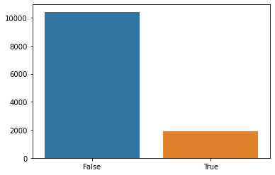

```
False    0.845255
True     0.154745
Name: Revenue, dtype: float64
```

```python
sns.barplot(data.Revenue.value_counts().index,data.Revenue.value_counts().values)
plt.show()
print(data.Revenue.value_counts(normalize=True))
```

**Plot the Pairplot for the complete dataset**

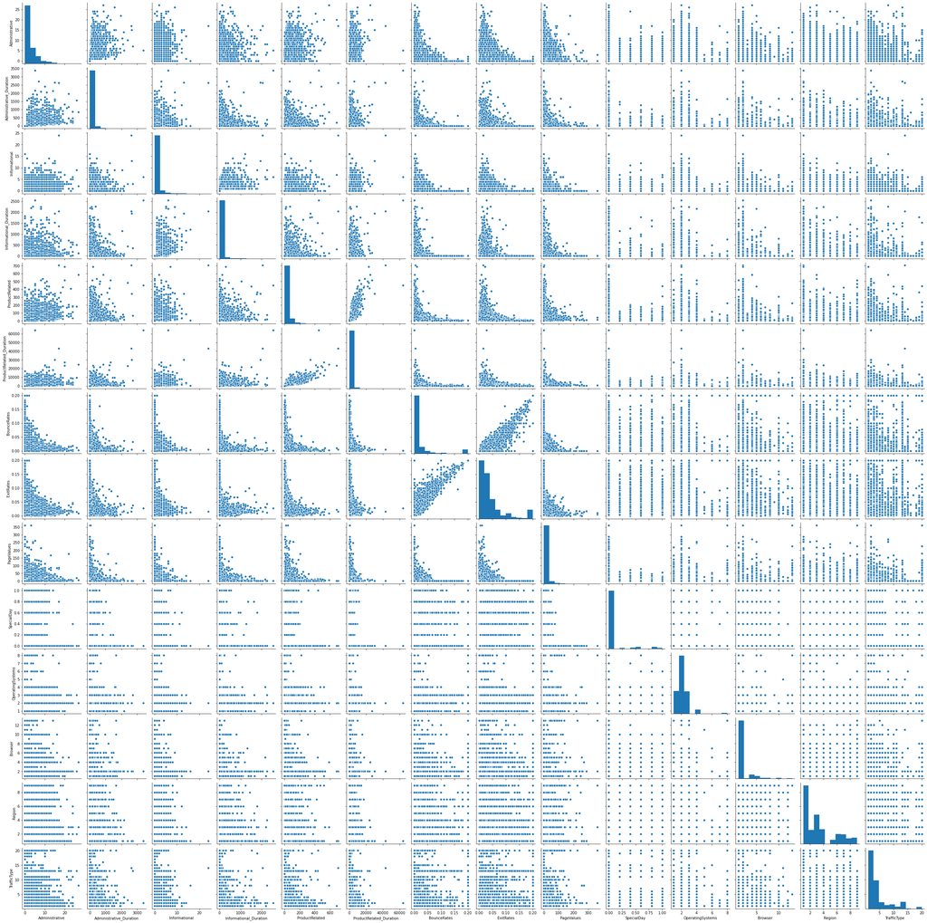

```python
sns.pairplot(data[data.dtypes[(data.dtypes=='int64')|(data.dtypes=='float64')].index])
plt.show()
```

**Check for Object Data types**

```python
data[data.dtypes[(data.dtypes=='object')|(data.dtypes=='bool')].index].head()
```

|  | Month | VisitorType | Weekend | Revenue |
| --- | --- | --- | --- | --- |
| 0 | Feb | Returning_Visitor | False | False |
| 1 | Feb | Returning_Visitor | False | False |
| 2 | Feb | Returning_Visitor | False | False |
| 3 | Feb | Returning_Visitor | False | False |
| 4 | Feb | Returning_Visitor | True | False |

```python
data.dtypes.value_counts()
```

```
int64      7
float64    7
object     2
bool       2
dtype: int64
```

**Check for outliers**

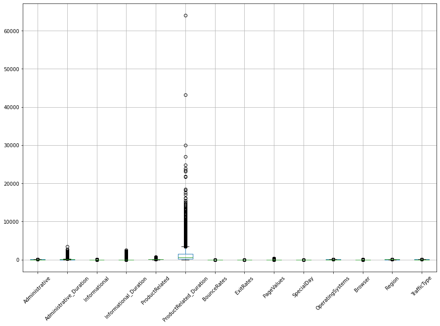

```python
continuous=data.dtypes[(data.dtypes=='int64')|(data.dtypes=='float64')].index
data_plot=data[continuous]

data_plot.boxplot(figsize=(15,10), rot=45);
```

**Plot Correlation Heatmap**

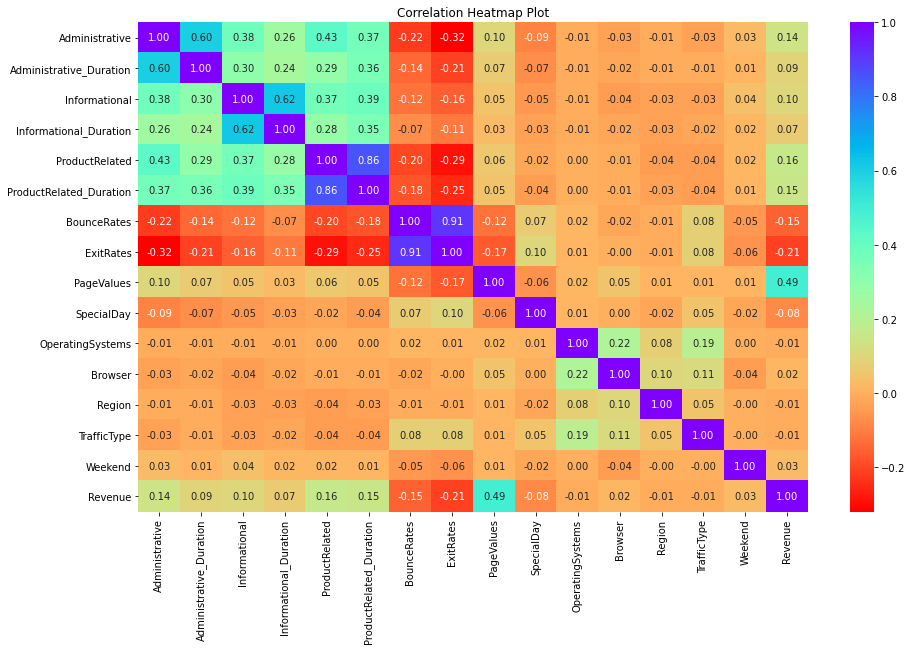

```python
plt.figure(figsize=(15,9))
sns.heatmap(round(data.corr(),2),fmt='.2f',annot=True,cmap='rainbow_r')
plt.title('Correlation Heatmap Plot')
plt.show()
```

Example inference:

**PageValues is moderately positively correlated with the target variable**

**BounceRates and ExitRates have high positive correlation**

**ProductRelated and ProductRelated_Duration have high positive correlation**

## Data Encoding

```python
X=data.iloc[:,:-1]
y=data.iloc[:,-1]
```

```python
vistype=pd.get_dummies(X.VisitorType,drop_first=True)
```

```python
from sklearn.preprocessing import LabelEncoder
le=LabelEncoder()
X['Month']=le.fit_transform(X.Month)
```

```python
X=pd.concat((X,vistype),axis=1)
X=X.drop(['VisitorType'],axis=1)
```

```python
X.head()
```

|  | Administrative | Administrative_Duration | Informational | Informational_Duration | ProductRelated | ProductRelated_Duration | BounceRates | ExitRates | PageValues | SpecialDay | Month | OperatingSystems | Browser | Region | TrafficType | Weekend | Other | Returning_Visitor |
| --- | --- | --- | --- | --- | --- | --- | --- | --- | --- | --- | --- | --- | --- | --- | --- | --- | --- | --- |
| 0 | 0 | 0.0 | 0 | 0.0 | 1 | 0.000000 | 0.20 | 0.20 | 0.0 | 0.0 | 2 | 1 | 1 | 1 | 1 | False | 0 | 1 |
| 1 | 0 | 0.0 | 0 | 0.0 | 2 | 64.000000 | 0.00 | 0.10 | 0.0 | 0.0 | 2 | 2 | 2 | 1 | 2 | False | 0 | 1 |
| 2 | 0 | 0.0 | 0 | 0.0 | 1 | 0.000000 | 0.20 | 0.20 | 0.0 | 0.0 | 2 | 4 | 1 | 9 | 3 | False | 0 | 1 |
| 3 | 0 | 0.0 | 0 | 0.0 | 2 | 2.666667 | 0.05 | 0.14 | 0.0 | 0.0 | 2 | 3 | 2 | 2 | 4 | False | 0 | 1 |
| 4 | 0 | 0.0 | 0 | 0.0 | 10 | 627.500000 | 0.02 | 0.05 | 0.0 | 0.0 | 2 | 3 | 3 | 1 | 4 | True | 0 | 1 |

## Splitting the data into Train and Test set

```python
X_train,X_test,y_train,y_test=train_test_split(X, y, test_size = 0.20, random_state = 123)
```

## Feature Scaling

```python
sc=StandardScaler()
```

```python
X_train=sc.fit_transform(X_train)
X_test=sc.transform(X_test)
```

## Building a Decision Tree Classifier Model and fit it on the Training Set

```python
dtc=DecisionTreeClassifier(random_state=123)
```

```python
dtc.fit(X_train,y_train)
```

```
DecisionTreeClassifier(random_state=123)
```

**Predictions on The training Set**

```python
prediction_dtc=dtc.predict(X_train)
```

**Check the Metrics for Predictions on the Training set**

[Accuracy Score, Classification Report, Confusion Matrix]

```
Accuracy for DecisionTreeClassifier model is
 1.0


Classification report for DecisionTreeClassifier model is
               precision    recall  f1-score   support

       False       1.00      1.00      1.00      8353
        True       1.00      1.00      1.00      1511

    accuracy                           1.00      9864
   macro avg       1.00      1.00      1.00      9864
weighted avg       1.00      1.00      1.00      9864



Confusion Matrix for DecisionTreeClassifier model is
```

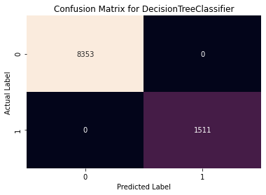

```python
models_names={dtc:'DecisionTreeClassifier'}

print('Accuracy for {} model is'.format(models_names[dtc]),'\n',accuracy_score(y_train,prediction_dtc))
print('\n')
print('Classification report for {} model is'.format(models_names[dtc]),'\n',classification_report(y_train,prediction_dtc))
print('\n')
print('Confusion Matrix for {} model is'.format(models_names[dtc]))
sns.heatmap(confusion_matrix(y_train,prediction_dtc),annot=True,fmt='d',cbar=False)
plt.title('Confusion Matrix for {}'.format(models_names[dtc]))
plt.xlabel('Predicted Label')
plt.ylabel('Actual Label')
plt.show()
```

## Building a Random Forest Classifier Model and fit it on the Training Set

```python
rfc=RandomForestClassifier(random_state=123)
```

```python
rfc.fit(X_train,y_train)
```

```
RandomForestClassifier(random_state=123)
```

**Predictions on The training Set**

```python
prediction_rfc=rfc.predict(X_train)
```

**Check the Metrics for Predictions on the Training set**

[Accuracy Score, Classification Report, Confusion Matrix]

```
Accuracy for RandomForestClassifier model is
 1.0


Classification report for RandomForestClassifier model is
               precision    recall  f1-score   support

       False       1.00      1.00      1.00      8353
        True       1.00      1.00      1.00      1511

    accuracy                           1.00      9864
   macro avg       1.00      1.00      1.00      9864
weighted avg       1.00      1.00      1.00      9864



Confusion Matrix for RandomForestClassifier model is
```

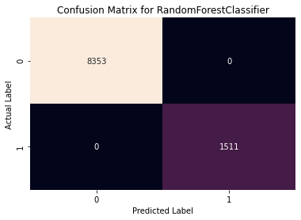

```python
models_names={dtc:'DecisionTreeClassifier',rfc:'RandomForestClassifier'}

print('Accuracy for {} model is'.format(models_names[rfc]),'\n',accuracy_score(y_train,prediction_rfc))
print('\n')
print('Classification report for {} model is'.format(models_names[rfc]),'\n',classification_report(y_train,prediction_rfc))
print('\n')
print('Confusion Matrix for {} model is'.format(models_names[rfc]))
sns.heatmap(confusion_matrix(y_train,prediction_rfc),annot=True,fmt='d',cbar=False)
plt.title('Confusion Matrix for {}'.format(models_names[rfc]))
plt.xlabel('Predicted Label')
plt.ylabel('Actual Label')
plt.show()
```

## Building an ANN Model and fit it on the Training Set

```python
mlp=MLPClassifier(hidden_layer_sizes=(500),solver='sgd',random_state=0,max_iter=500)
```

```python
mlp.fit(X_train,y_train)
```

```
MLPClassifier(hidden_layer_sizes=500, max_iter=500, random_state=0,
              solver='sgd')
```

**Predictions on The training Set**

```python
prediction_ann=mlp.predict(X_train)
```

**Check the Metrics for Predictions on the Training set**

[Accuracy Score, Classification Report, Confusion Matrix]

```
Accuracy for ANN model is
 0.9048053527980535


Classification report for ANN model is
               precision    recall  f1-score   support

       False       0.92      0.97      0.95      8353
        True       0.76      0.56      0.64      1511

    accuracy                           0.90      9864
   macro avg       0.84      0.76      0.79      9864
weighted avg       0.90      0.90      0.90      9864



Confusion Matrix for ANN model is
```

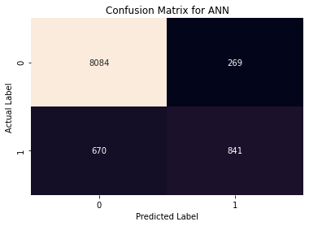

```python
models_names={dtc:'DecisionTreeClassifier',rfc:'RandomForestClassifier',mlp:'ANN'}

print('Accuracy for {} model is'.format(models_names[mlp]),'\n',accuracy_score(y_train,prediction_ann))
print('\n')
print('Classification report for {} model is'.format(models_names[mlp]),'\n',classification_report(y_train,prediction_ann))
print('\n')
print('Confusion Matrix for {} model is'.format(models_names[mlp]))
sns.heatmap(confusion_matrix(y_train,prediction_ann),annot=True,fmt='d',cbar=False)
plt.title('Confusion Matrix for {}'.format(models_names[mlp]))
plt.xlabel('Predicted Label')
plt.ylabel('Actual Label')
plt.show()
```

## Comparing Models on The test set

```python
models=[dtc,rfc,mlp]
models_names={dtc:'DecisionTreeClassifier',rfc:'RandomForestClassifier',mlp:'ANN'}
```

```
Accuracy for DecisionTreeClassifier model is
 0.85117599351176


Classification report for DecisionTreeClassifier model is
               precision    recall  f1-score   support

       False       0.91      0.91      0.91      2069
        True       0.54      0.55      0.54       397

    accuracy                           0.85      2466
   macro avg       0.73      0.73      0.73      2466
weighted avg       0.85      0.85      0.85      2466



Confusion Matrix for DecisionTreeClassifier model is
```

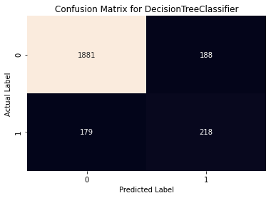

```
Accuracy for RandomForestClassifier model is
 0.8913219789132197


Classification report for RandomForestClassifier model is
               precision    recall  f1-score   support

       False       0.92      0.96      0.94      2069
        True       0.72      0.54      0.61       397

    accuracy                           0.89      2466
   macro avg       0.82      0.75      0.78      2466
weighted avg       0.88      0.89      0.88      2466



Confusion Matrix for RandomForestClassifier model is
```

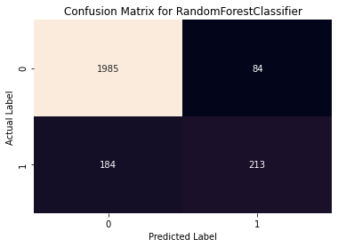

```
Accuracy for ANN model is
 0.8815896188158961


Classification report for ANN model is
               precision    recall  f1-score   support

       False       0.91      0.96      0.93      2069
        True       0.68      0.49      0.57       397

    accuracy                           0.88      2466
   macro avg       0.80      0.72      0.75      2466
weighted avg       0.87      0.88      0.87      2466



Confusion Matrix for ANN model is
```

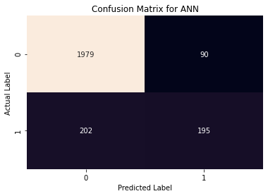

```python
for i in models:
    i.fit(X_train,y_train)
    print('Accuracy for {} model is'.format(models_names[i]),'\n',accuracy_score(y_test,i.predict(X_test)))
    print('\n')
    print('Classification report for {} model is'.format(models_names[i]),'\n',classification_report(y_test,i.predict(X_test)))
    print('\n')
    print('Confusion Matrix for {} model is'.format(models_names[i]))
    sns.heatmap(confusion_matrix(y_test,i.predict(X_test)),annot=True,fmt='d',cbar=False)
    plt.title('Confusion Matrix for {}'.format(models_names[i]))
    plt.xlabel('Predicted Label')
    plt.ylabel('Actual Label')
    plt.show()
```

**Compare ROC curves and Calculate Area under the curve for all models**

```
Area under the curve for Decision Tree Classification Model is 0.7291266178309287
Area under the curve for Random Forest Classification Model is 0.9149779703503682
Area under the curve for Artificial Neural Network Model is 0.8979635813794371
```

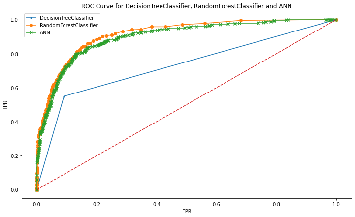

```python
print('Area under the curve for Decision Tree Classification Model is',roc_auc_score(y_test,dtc.predict_proba(X_test)[:,1]))
print('Area under the curve for Random Forest Classification Model is',roc_auc_score(y_test,rfc.predict_proba(X_test)[:,1]))
print('Area under the curve for Artificial Neural Network Model is',roc_auc_score(y_test,mlp.predict_proba(X_test)[:,1]))

plt.figure(figsize=(12,7))
fpr_dtc, tpr_dtc, thresholds = roc_curve(y_test, dtc.predict_proba(X_test)[:,1])
plt.plot(fpr_dtc, tpr_dtc, marker='.')

fpr_rfc, tpr_rfc, thresholds = roc_curve(y_test, rfc.predict_proba(X_test)[:,1])
plt.plot(fpr_rfc, tpr_rfc, marker='o')

fpr_ann, tpr_ann, thresholds = roc_curve(y_test, mlp.predict_proba(X_test)[:,1])
plt.plot(fpr_ann, tpr_ann, marker='x',)
plt.plot([0, 1], [0, 1], linestyle='--')

plt.title('ROC Curve for {}'.format('DecisionTreeClassifier, RandomForestClassifier and ANN'))
plt.xlabel('FPR')
plt.ylabel('TPR')
plt.legend(models_names.values())
plt.show()
```

## Conclusion

1. RF performs better than ANN and Decision Tree on the test set
2. Decision Tree and Random Forest overfits the Train Dataset with 1.0 Accuracy Score
3. ANN has the least accuracy score for training set
4. ANN have ~89% area under the curve for testing set
5. The Accuracy for ANN and RF is similar ~88% for test set

You can work around n_estimators for Random Forest and try grid_search or increase layers in the ANN, to make better predictions.